# R Markdown

2023-09-12

## What is R Markdown

- A way of creating documents with chunks of code, visualizations, etc. embedded into it
- Relies on two packages: knitr and Pandoc
  - knitr allows for the code to be embedded in the markdown document
  - Pandoc allows for the document to be exported in multiple file formats

## Benefits

- Simplicity (allegedly)
- Can cover several functions
- Cannot do everything (in-depth typesetting)
- Convenient way to create documents with good formatting

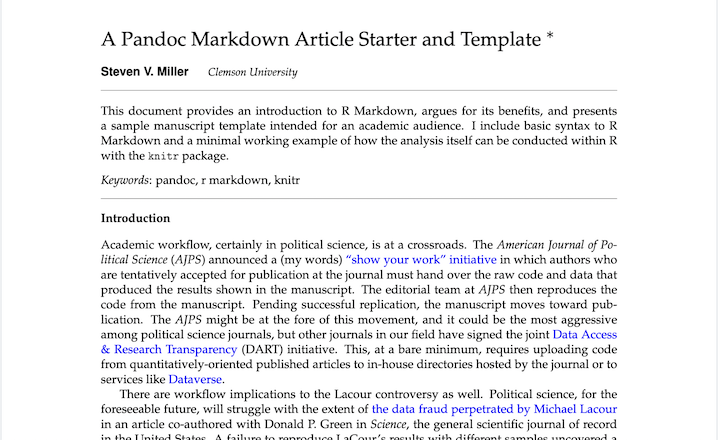

- Can also be used to create websites

[figure not shown]

- And dashboards

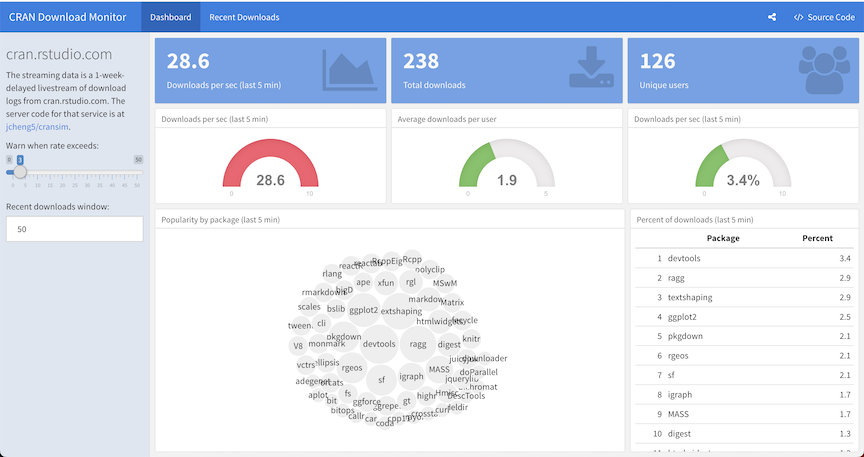

- We can also embed code right into the program

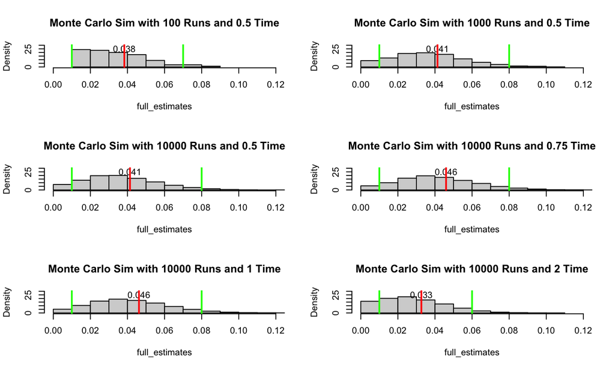

- This is the code used for the previous plots

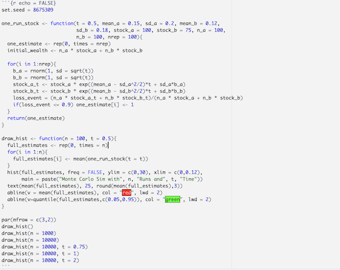

## All Uses

-Convert R Markdown into multiple file types

-Create notebooks with interactive code (similar to Jupyter notebook)

-Make presentations (like this one)

-Create dashboards

-Shiny apps (Shiny is a package for creating websites in R)

-Journal articles

-Write books

-Create websites

Allaire, J. J., and Yihui Xie. “R Markdown: The Definitive Guide.” Bookdown.Org, 15 May 2023, bookdown.org/yihui/rmarkdown/.

## How to Get Started

-First, open a new ‘R Markdown’ File

[figure not shown]

-Next, choose the option you would like to use + Document + Presentation + Shiny App + From Template

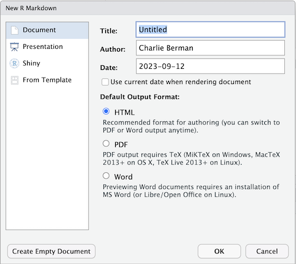

Step 2.

- Add new chunks and text
  - Chunks have the code, text is the text you see in the document

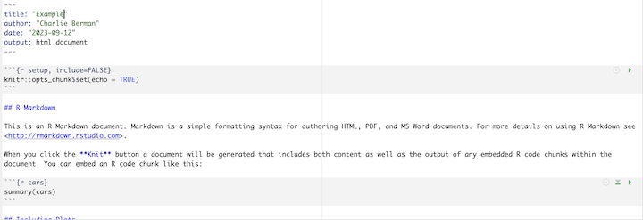

Step 3.